# RestoreDART sample size and filtering checks

#### Pixel and polygon counts, post-filtering

Pixel counts per polygon, excluding zeros, *i.e.* no pixels present for that `'tx_coarse'` x `'us_l4name'` combination):

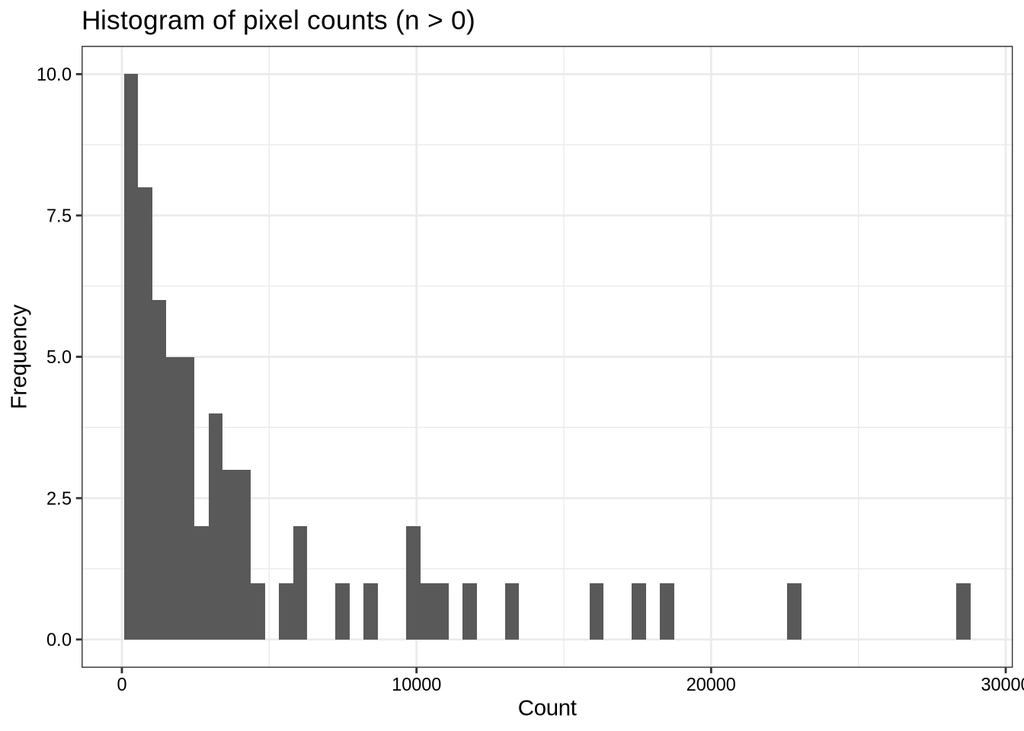

**Figure.** X axis: the pixel count of a single treatment x ecoregion cell. Y axis: how many such cells fall in that count bin (frequency). Cells with zero pixels are excluded, so the distribution describes only combinations that exist in the data. No groupings, colours or facets.

Polygon count table, plotted as histogram, zeroes excluded:

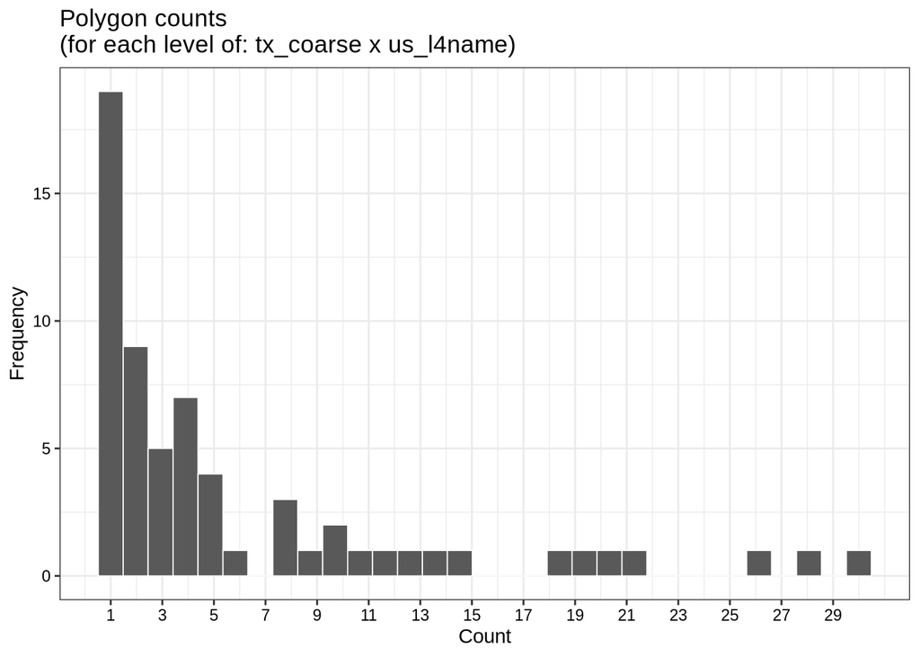

**Figure.** X axis: the number of distinct polygons in a single treatment x ecoregion cell, with one break per integer. Y axis: how many cells have that polygon count (frequency). Zero-polygon cells are excluded. No groupings, colours or facets.

Polygon count table: for each year since treatment, how many distinct polygons contribute at least one pixel that year.

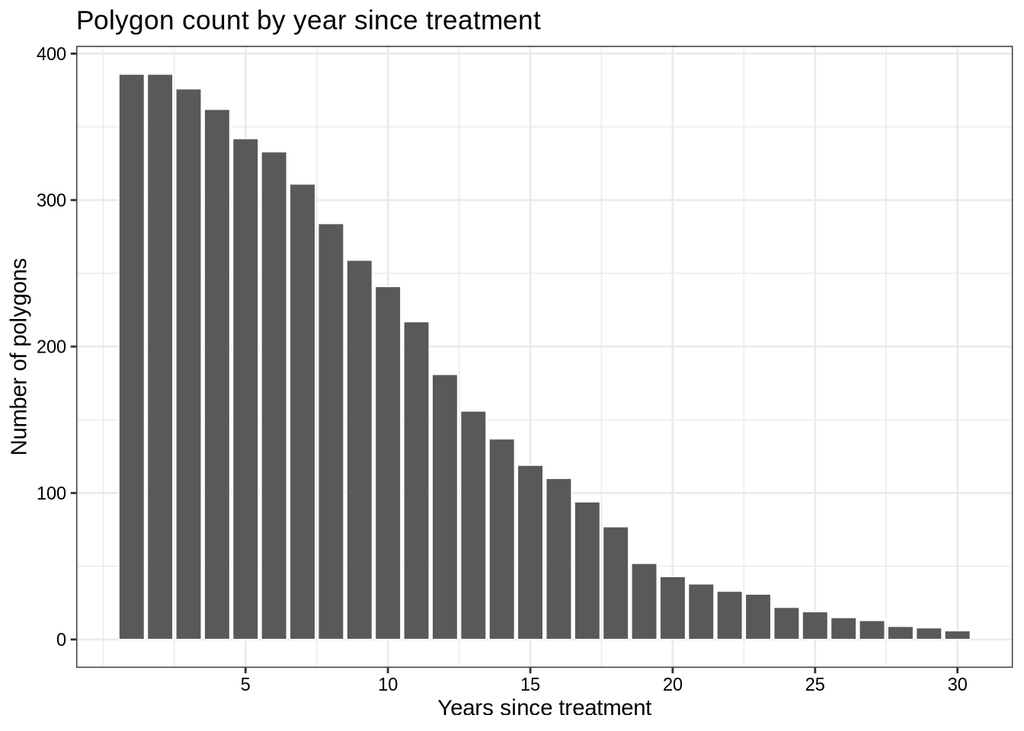

**Figure.** X axis: years since treatment, labelled every 5 years. Y axis: the number of distinct polygons contributing at least one pixel in that year - i.e. how many independent spatial replicates back that year, which is a different quantity from the year’s pixel count. No groupings, colours or facets.

#### Significant DART effects, by covariate

How often a significant effect occurred, first as one rate for the whole objective and then broken apart by fine objective, by treatment and by ecoregion. All of it is cross-sectional - the time dimension is the next subsection - and all of it reports the *intended* effect, since every level on these axes shares this objective’s management goal.

##### How many pixels have a significant DART result?

DART results are considered significant if the confidence intervals for each DART estimate do not include zero.

| Objective | Cover | Total Pixels | % Significant | % Significant Positive | % Significant Negative |
| --- | --- | --- | --- | --- | --- |
| increase_shr | SHR | 285880 | 23.5 | 14.9 | 8.6 |

**Table.** One row for this objective x cover response: the total pixel count, the share of those pixels with a significant DART result, and that share split by the raw sign of the effect. The two directional columns sum to the overall column up to rounding. For increase_shr, a positive effect is the *intended* one (see the terminology section above), so the “% Significant Positive” column is the intended result and the other is unintended.

The same total expressed as intended versus unintended rather than as raw sign: 23.5% of all DART pixels were significant, with the treatment producing the intended (positive) effect in 14.9% of pixels and an unintended (negative) effect in 8.6% of pixels, relative to the assigned objective.

##### How do DART significance patterns change

| Objective (Fine) | Total Pixels | Significant Intended Pixels | % Significant Intended |
| --- | --- | --- | --- |
| increase_pfg, increase_shr, decrease_tre, decrease_afg | 11510 | 3932 | 34.16 |
| increase_shr, decrease_tre, null_afg | 352 | 96 | 27.27 |
| increase_pfg, increase_shr, increase_afg, decrease_tre | 12400 | 2995 | 24.15 |
| increase_pfg, increase_shr, increase_afg | 4575 | 927 | 20.26 |
| increase_pfg, increase_shr, decrease_tre, null_afg | 8947 | 1557 | 17.40 |
| increase_pfg, increase_shr, decrease_tre | 85577 | 13763 | 16.08 |
| increase_pfg, increase_shr | 101424 | 14156 | 13.96 |
| increase_shr, decrease_tre | 15794 | 2116 | 13.40 |
| increase_pfg, increase_shr, decrease_afg | 23068 | 2803 | 12.15 |
| increase_shr | 2525 | 68 | 2.69 |
| increase_shr, decrease_afg | 12354 | 159 | 1.29 |
| increase_shr, decrease_afg, decrease_tre | 324 | 4 | 1.23 |
| increase_pfg, increase_shr, null_afg | 4713 | 45 | 0.95 |
| increase_pfg, increase_shr, increase_tre | 2205 | 14 | 0.63 |
| increase_pfg, increase_shr, increase_afg, increase_tre | 112 | 0 | 0.00 |

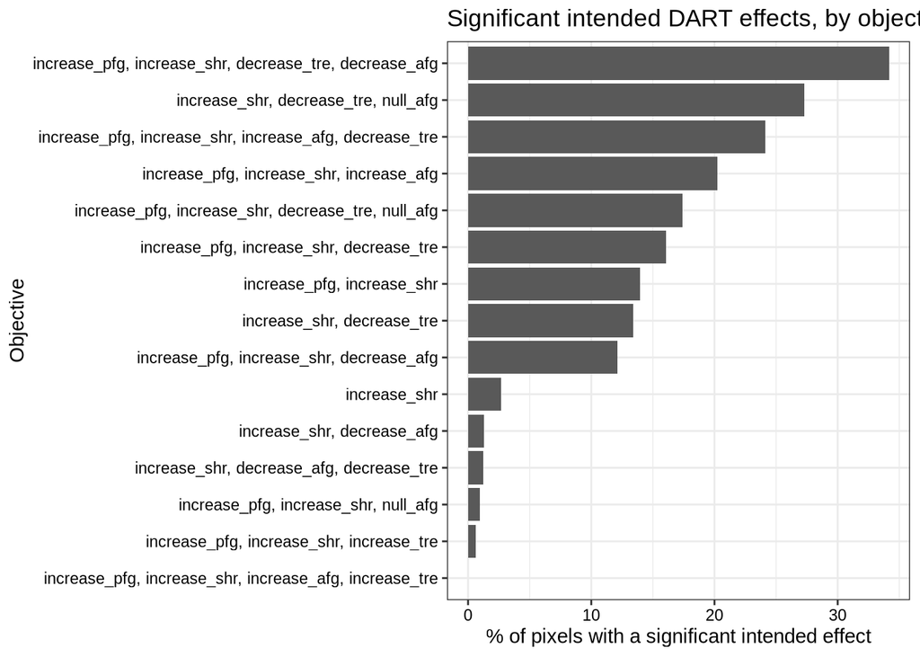

**Table and figure.** One row (and one bar) per *fine* objective string - the full comma-separated objective assignment of a pixel, so a pixel with compound objectives appears under its own combination rather than under each part. X axis of the figure: the percentage of that objective’s pixels with a significant *intended* effect - i.e. significant and in the direction increase_shr was aiming for, which for this objective is a positive effect. Y axis: the fine objective, ordered by that percentage. Bars are a single grey fill; no colour grouping or facets. Across the 15 fine objectives present, the rate ranges from 0.00% to 34.16%. Because the sign is taken relative to this objective’s goal, these percentages are comparable *within* this section but not against another objective’s version of the same figure - the cross-objective tables at the end of the report use the raw sign for that reason.

Repeated for treatment:

| Treatment | Total Pixels | Significant Intended Pixels | % Significant Intended |
| --- | --- | --- | --- |
| soil disturbance | 2100 | 677 | 32.24 |
| prescribed burn;soil disturbance;vegetation removal | 3780 | 940 | 24.87 |
| seeding;soil disturbance;vegetation removal | 13677 | 3349 | 24.49 |
| seeding;vegetation removal | 35902 | 8507 | 23.70 |
| prescribed burn;seeding;soil disturbance;vegetation removal | 1059 | 242 | 22.85 |
| soil disturbance;vegetation removal | 6228 | 976 | 15.67 |
| seeding | 82001 | 12589 | 15.35 |
| seeding;soil disturbance | 77788 | 9620 | 12.37 |
| prescribed burn;vegetation removal | 1515 | 177 | 11.68 |
| vegetation removal | 33076 | 3584 | 10.84 |
| prescribed burn | 26549 | 1960 | 7.38 |
| prescribed burn;soil disturbance | 2205 | 14 | 0.63 |

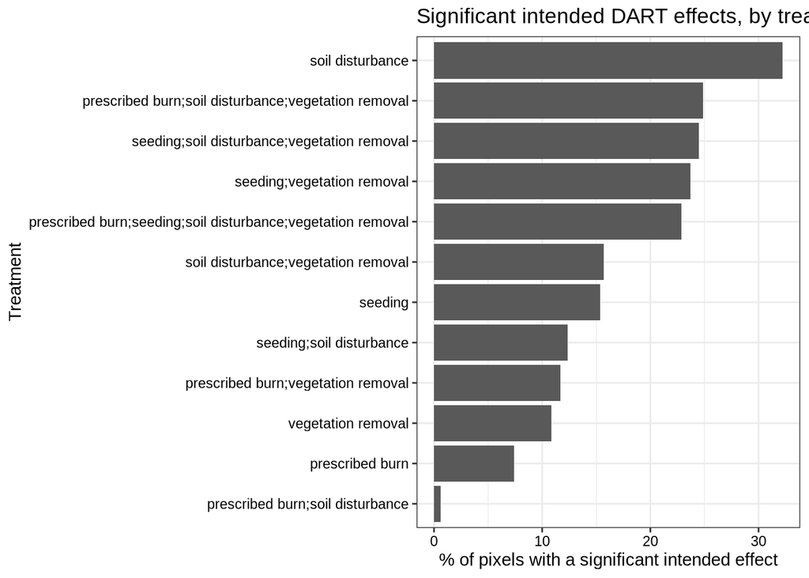

**Table and figure.** As above, grouped by coarse treatment (`'tx_coarse'`). X axis: % of that treatment’s pixels with a significant *intended* (positive) effect. Y axis: treatment, ordered by that percentage. Single grey fill, no facets. Range across the 12 treatments: 0.63% to 32.24%. This is the closest thing in the report to a per-treatment success rate for this objective, since the direction counted is the one the treatment was trying to produce.

Lastly, for ecoregion:

| Ecoregion | Total Pixels | Significant Intended Pixels | % Significant Intended |
| --- | --- | --- | --- |
| High Elevation Carbonate Mountains | 1974 | 1516 | 76.80 |
| Crystalline Mid-Elevation Forests | 451 | 141 | 31.26 |
| Woodland- and Shrub-Covered Low Mountains | 43709 | 10961 | 25.08 |
| Monticello-Cortez Uplands | 1031 | 195 | 18.91 |
| Semiarid Foothills | 32102 | 5953 | 18.54 |
| Northern Uinta Basin Slopes | 4383 | 713 | 16.27 |
| Dissected High Lava Plateau | 7575 | 1210 | 15.97 |
| Semiarid Hills and Low Mountains | 5844 | 876 | 14.99 |
| Mountain Valleys | 1054 | 157 | 14.90 |
| Semiarid Benchlands and Canyonlands | 77752 | 11326 | 14.57 |
| Foothill Shrublands and Low Mountains | 33030 | 3816 | 11.55 |
| Escarpments | 5926 | 607 | 10.24 |
| Sagebrush Basins and Slopes | 43694 | 4361 | 9.98 |
| Wasatch Montane Zone | 4253 | 241 | 5.67 |
| Shadscale-Dominated Saline Basins | 14705 | 504 | 3.43 |
| Eastern Mojave Basins | 576 | 9 | 1.56 |
| Shale Deserts and Sedimentary Basins | 4329 | 43 | 0.99 |
| Rolling Sagebrush Steppe | 313 | 3 | 0.96 |
| Eastern Mojave Mountain Woodland and Shrubland | 3179 | 3 | 0.09 |

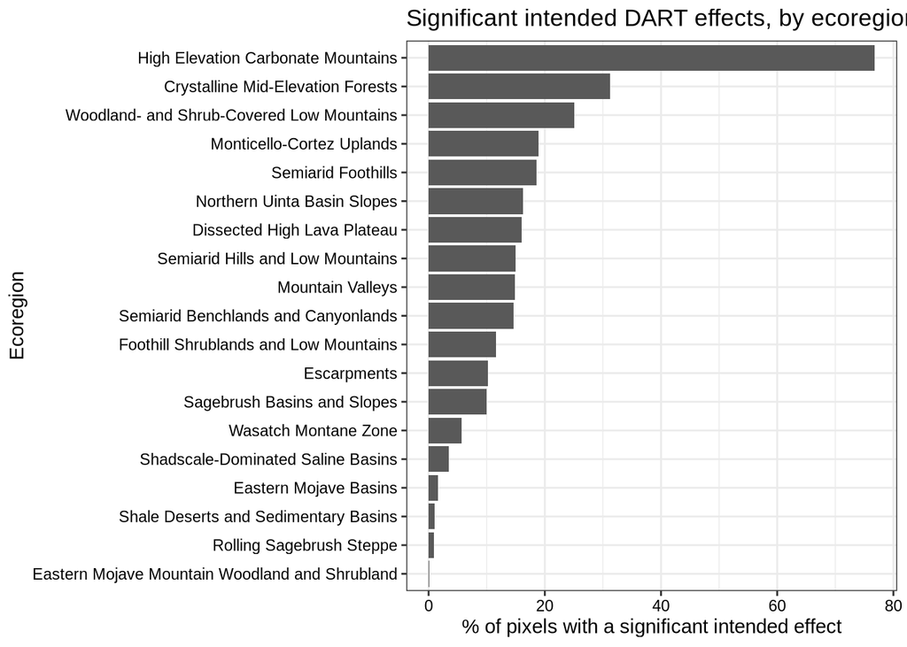

**Table and figure.** As above, grouped by level-IV ecoregion (`'us_l4name'`). X axis: % of that ecoregion’s pixels with a significant *intended* (positive) effect. Y axis: ecoregion, ordered by that percentage. Single grey fill, no facets. Range across the 19 ecoregions: 0.09% to 76.80%.

#### Significant DART effects, through time

The same effects along the time axis and against the covariates that interact with it: how often a significant effect occurred in each year since treatment, how large those effects were and when they peaked, and how the per-polygon peak years distribute across treatments and ecoregions. Read the two halves as separate questions - a year can carry a high significance rate with small effects, or the reverse.

##### How does time since treatment affect significance?

This section attempts to answer two questions:

1. How *often* does a significant effect show up in a given year? The stacked-direction figure immediately below.
2. How *large* are those effects? The mean-effect table and figure further down. A year can have a handful of significant pixels that each moved a long way, or many pixels that each moved a little, and those are different results.

No weighting is used anywhere in this section. The mean effect per year is a plain arithmetic mean of `effect` over the significant pixels in that year, split by direction of effect, so the reported peak is the year whose significant pixels actually moved furthest rather than a significance-weighted compromise across the whole time series. Some weighting methods were checked and did not improve the results - see `weight_testing_summary.Rmd` for that analysis.

Everything in this section is drawn on the **truncated** series: for this objective no year fell below the 10-significant-pixel threshold, so the full record to year 30 is used. This is what stops a peak year being reported from the part of the record where almost nothing was significant; it also means the x axis here can end earlier than another objective’s, so the two are not read off the same range.

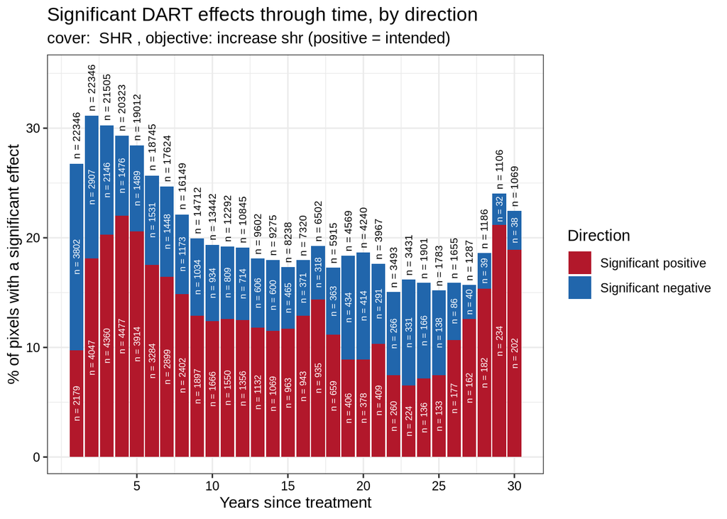

**Figure.** X axis: years since treatment, one bar per year, labelled every 5 years. Y axis: the percentage of that year’s pixels with a significant DART effect - the full height of a bar is the year’s overall % significant, and it is a percentage of all pixels observed in that year, not of the significant ones. Fill: the direction of the significant effect, splitting each bar into a blue *significant negative* component and a red *significant positive* component; the intended direction for this objective (positive) is the segment drawn against the axis, with the unintended direction stacked above it. Fill colours mean the same thing in every direction figure in this report. There are no facets or other groupings.

Two different sample sizes are labelled on each bar, and they are **not** meant to sum to each other:

- The rotated label sitting *above* each bar is that year’s **group total** - every pixel observed in that year, significant or not. It says how much data is behind the bar, and it is the denominator of the percentage on the Y axis.
- The white label *inside* each stacked segment is the number of pixels that were significant **and** in that segment’s direction. These two are the sample sizes behind the two segment heights themselves.

So the two segment labels add up to the number of *significant* pixels in that year, which is generally far smaller than the group total above the bar, because most pixels in a year are not significant. Reading down a tall bar with a small group total is therefore a different situation from a short bar with a large one, which is exactly why both numbers are drawn. Segments too short to hold their label legibly are left unlabelled to avoid white text spilling onto the panel background.

- Treatment was **most** effective (highest % significant pixels) at year 2 (31.1% significant).
- Treatment was **least** effective (lowest % significant pixels) at year 22 (15.1% significant).

##### How large were the significant effects in each year?

The figure below switches from counting significant pixels to measuring them: among significant pixels only, what was the mean DART effect in each year since treatment, and in which year was that mean largest? Positive and negative effects are summarized separately throughout.

| Direction | Peak Year | Mean Effect at Peak | SE | Significant Pixels at Peak | Last Year Observed | Peak Censored? |
| --- | --- | --- | --- | --- | --- | --- |
| negative | 2 | -11.8737 | 0.1131 | 2907 | 30 | FALSE |
| positive | 20 | 14.0138 | 0.3377 | 378 | 30 | FALSE |

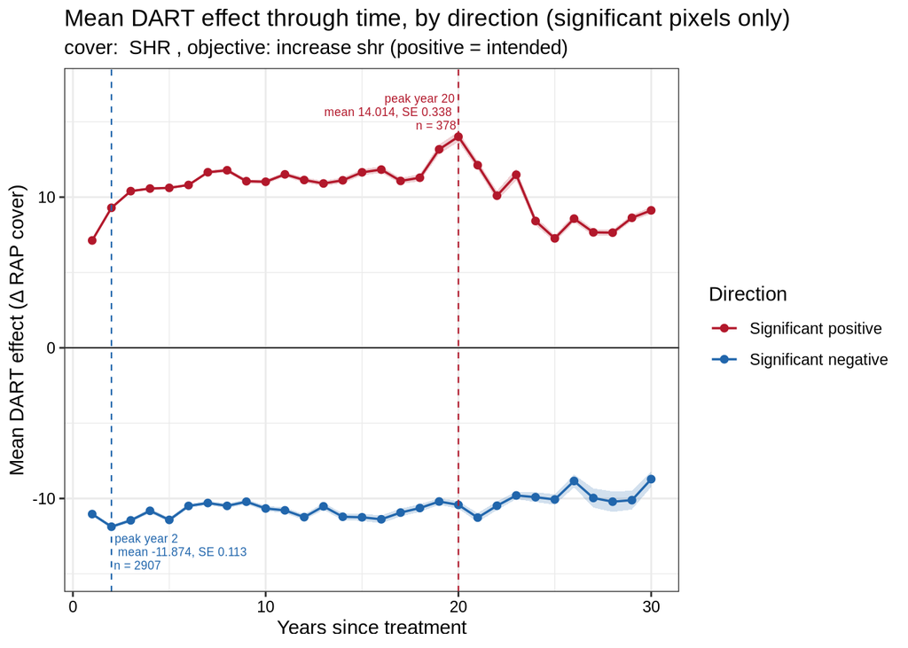

**Table.** One row per direction of effect: the year in which the mean effect over significant pixels was largest in magnitude, that mean, its SE, the number of significant pixels behind it, the last year observed for that direction, and whether the peak is censored (lands on that last year).

**Figure.** X axis: years since treatment. Y axis: the mean DART effect (Δ RAP cover) among *significant pixels only* in that year, computed separately for each direction - so the two series sit either side of the zero line by construction and are never averaged into a single number. Colour: direction of the effect (red = significant positive, blue = significant negative), using the same colours as the stacked figure above. The shaded band around each line is that year × direction mean ± 1 SE: it is sampling uncertainty in the *mean* effect, not the spread of individual pixel effects, so it narrows mainly where a year has many significant pixels. A year × direction cell backed by a single significant pixel has no SE and is drawn as a bare point, keeping the line through it unbroken. Dashed vertical lines mark each direction’s peak year from the table above, labelled with the mean effect at the peak, its SE, and the number of significant pixels behind it. Non-significant pixels are excluded outright rather than entered as zeros, and no weighting is applied anywhere. There are no facets or other groupings.

- Significant **negative** effects were largest at year 2 (mean effect -11.8737, SE 0.1131, n = 2907 significant pixels).
- Significant **positive** effects were largest at year 20 (mean effect 14.0138, SE 0.3377, n = 378 significant pixels).

Note that the year with the largest mean effect need not be the year with the most significant pixels: the two questions can peak at different times, and a peak that lands on the last observed year is flagged as censored above for the same reason as in the by-polygon table further down.

| Objective | Cover | Year Bin | Total Pixels | Mean % Significant | Mean % Significant Positive | Mean % Significant Negative |
| --- | --- | --- | --- | --- | --- | --- |
| increase_shr | SHR | 1-5 | 105532 | 29.18 | 17.98 | 11.20 |
| increase_shr | SHR | 6-10 | 80672 | 22.64 | 15.06 | 7.59 |
| increase_shr | SHR | 11-15 | 50252 | 18.44 | 12.08 | 6.36 |
| increase_shr | SHR | 16+ | 49424 | 17.74 | 11.01 | 6.73 |

**Table.** The same significance rates as the year-by-year figure, collapsed into 1-5, 6-10, 11-15 and 16+ years since treatment. One row per bin; percentages are of all pixels in that bin, and the two directional columns sum to the overall column up to rounding.

| Treatment | N Polygons | Mean Year of Peak Sig. | SD | Min | Max | % Censored (peak at last obs. year) |
| --- | --- | --- | --- | --- | --- | --- |
| prescribed burn | 4 | 6.25 | 2.87 | 2 | 8 | 0.0 |
| prescribed burn;seeding;soil disturbance;vegetation removal | 3 | 1.67 | 0.58 | 1 | 2 | 0.0 |
| prescribed burn;soil disturbance | 1 | 1.00 |  | 1 | 1 | 0.0 |
| prescribed burn;soil disturbance;vegetation removal | 1 | 10.00 |  | 10 | 10 | 0.0 |
| prescribed burn;vegetation removal | 2 | 5.50 | 6.36 | 1 | 10 | 0.0 |
| seeding | 98 | 3.58 | 3.68 | 1 | 15 | 3.1 |
| seeding;soil disturbance | 97 | 4.70 | 5.01 | 1 | 23 | 6.2 |
| seeding;soil disturbance;vegetation removal | 26 | 4.77 | 3.67 | 1 | 16 | 3.8 |
| seeding;vegetation removal | 78 | 2.95 | 3.07 | 1 | 24 | 6.4 |
| soil disturbance | 6 | 4.00 | 1.79 | 2 | 7 | 0.0 |
| soil disturbance;vegetation removal | 8 | 3.38 | 2.97 | 1 | 10 | 0.0 |
| vegetation removal | 62 | 3.44 | 2.38 | 1 | 9 | 17.7 |

| Ecoregion | N Polygons | Mean Year of Peak Sig. | SD | Min | Max | % Censored (peak at last obs. year) |
| --- | --- | --- | --- | --- | --- | --- |
| Crystalline Mid-Elevation Forests | 1 | 1.00 |  | 1 | 1 | 0.0 |
| Dissected High Lava Plateau | 8 | 2.50 | 1.60 | 1 | 5 | 0.0 |
| Eastern Mojave Basins | 1 | 1.00 |  | 1 | 1 | 0.0 |
| Eastern Mojave Mountain Woodland and Shrubland | 3 | 1.33 | 0.58 | 1 | 2 | 0.0 |
| Escarpments | 7 | 4.00 | 3.27 | 1 | 9 | 0.0 |
| Foothill Shrublands and Low Mountains | 6 | 3.33 | 3.14 | 1 | 9 | 0.0 |
| High Elevation Carbonate Mountains | 1 | 4.00 |  | 4 | 4 | 0.0 |
| Monticello-Cortez Uplands | 5 | 3.40 | 3.58 | 1 | 9 | 0.0 |
| Mountain Valleys | 7 | 2.14 | 1.68 | 1 | 5 | 0.0 |
| Northern Uinta Basin Slopes | 5 | 2.80 | 2.05 | 1 | 5 | 20.0 |
| Rolling Sagebrush Steppe | 2 | 1.00 | 0.00 | 1 | 1 | 0.0 |
| Sagebrush Basins and Slopes | 66 | 3.32 | 3.69 | 1 | 22 | 9.1 |
| Semiarid Benchlands and Canyonlands | 115 | 4.07 | 3.62 | 1 | 16 | 7.0 |
| Semiarid Foothills | 56 | 3.54 | 2.97 | 1 | 12 | 3.6 |
| Semiarid Hills and Low Mountains | 8 | 7.75 | 7.91 | 1 | 24 | 0.0 |
| Shadscale-Dominated Saline Basins | 14 | 3.36 | 2.37 | 1 | 10 | 0.0 |
| Shale Deserts and Sedimentary Basins | 4 | 4.75 | 4.35 | 1 | 9 | 0.0 |
| Wasatch Montane Zone | 6 | 3.50 | 2.07 | 1 | 6 | 16.7 |
| Woodland- and Shrub-Covered Low Mountains | 71 | 4.46 | 4.75 | 1 | 23 | 11.3 |

**Tables.** Each polygon is reduced to the single year in which its own % significant pixels was highest (“peak significance year”); those per-polygon peak years are then summarized across polygons, by treatment in the first table and by ecoregion in the second. Columns: number of polygons behind the row, mean / SD / min / max of the peak year, and the percentage of polygons whose peak fell on the last year they were observed. A polygon’s peak year is flagged as “censored” in those cases, because we can’t rule out that significance was still rising beyond the end of the available time series. Note that “last year observed” now means the last year *retained* after the late-year truncation described above, so where a series was truncated the censoring flag is partly an artefact of the threshold rather than of the record itself - it marks the end of the analysable series, not necessarily the end of the data. What that censoring implies is taken up under *Interpretation* at the end of the report.

#### Overall results and interpretation

##### Summary statistics

What the three sample-size filters cost this objective x cover response, in one row - the same quantities reported in prose under *Results after dropping* above, gathered here so that this subsection stands on its own. The identical row appears in the cross-objective filtering log in `2_make_DART_results.Rmd`, where it can be read against the other objectives.

| Objective | Cover | Min Pixels per Tx x Eco | # Tx x Eco Excluded | # Tx Depopulated | # Eco Depopulated | Min Pixels per Year | Year Truncated At | # Years Dropped | % Pixels Lost | # Tx Absent | # Eco Absent |
| --- | --- | --- | --- | --- | --- | --- | --- | --- | --- | --- | --- |
| increase_shr | SHR | 300 | 27 | 0 | 0 | 10 | NA | 0 | 1.2 | 1 | 8 |

**Table.** One row for this objective x cover response. `% Pixels Lost` is the combined cost of all three filters, not the cell filter alone. `# Tx Absent` / `# Eco Absent` count levels missing from the post-filter data for any reason, which is a different quantity from the two depopulated columns: a level that only ever appeared in sparse cells disappears without the depopulation filter being involved.

Post-filter, this objective x cover response retains 285880 pixels across 12 treatment level(s) and 19 ecoregion level(s), the smallest surviving totals being 1059 pixels for a treatment and 313 for an ecoregion, against a per-cell threshold of 300.

##### Interpretation

- Mostly same considerations as `increase_pfg`
- Time effects are negative immediately after treatment, then stay generally positive
- Treatment looked generally successful.

## Overall results and interpretation, all objectives

The five objective x cover response sections above each end with their own summary statistics and interpretation, written next to the evidence they describe. This section puts the same material side by side, which is where one objective can be read against another. Nothing here is a second copy: the filtering table is compiled from the same per-objective rows, and the interpretation text is emitted from the same character vectors those sections define, so the two presentations cannot disagree.

Two standing caveats apply to everything below. The objective groupings are **not a partition** - a pixel counts toward an objective if it fell in any part of that objective, so multi-objective treatments appear in several groupings and parts of the dataset are counted more than once. And an objective/response pairing is only included when the response cover type matches the objective’s target cover, with bare ground the sole exception.

### Sample-size filtering across objectives

| Objective | Cover | Min Pixels per Tx x Eco | # Tx x Eco Excluded | # Tx Depopulated | # Eco Depopulated | Min Pixels per Year | Year Truncated At | # Years Dropped | % Pixels Lost | # Tx Absent | # Eco Absent |
| --- | --- | --- | --- | --- | --- | --- | --- | --- | --- | --- | --- |
| decrease_afg | AFG | 300 | 20 | 0 | 0 | 10 | 27 | 2 | 2.53 | 3 | 4 |
| decrease_shr | SHR | 300 | 8 | 0 | 0 | 10 | 33 | 1 | 0.50 | 1 | 2 |
| decrease_tre | TRE | 10 | 0 | 0 | 0 | 10 | NA | 0 | 0.00 | 0 | 0 |
| increase_pfg | PFG | 300 | 27 | 0 | 0 | 10 | NA | 0 | 0.48 | 1 | 6 |
| increase_shr | SHR | 300 | 27 | 0 | 0 | 10 | NA | 0 | 1.20 | 1 | 8 |

**Table.** One row per objective x cover response. `% Pixels Lost` is the combined cost of all three filters. Read the `Min Pixels per Tx x Eco` column before comparing any two rows of any compiled table in this project: where it differs, the rows describe differently filtered samples.

### Interpretation by objective

#### cover: AFG , objective: decrease afg

- This was the only objective that achieved mostly the opposite of what it intended in that the direction of effect was usually positive, while the attempted effect was negative. I would hypothesize that the very strong unintended-effect result has to do with disturbance effects or the interact effects of compound objectives.
- Significance patterns over fine objectives are highly heterogenous, but too complex to interpret casually.
- Significance patterns over treatments are also highly heterogenous, but similarily complex.
- Significance patterns over ecoregion probably require some environmental context, or an expert eye. For example I don’t have enough personal knowledge to guess why `Uinta Basin Floor` was so much higher than the other ecoregions.”
- Treatment was generally not successful.

#### cover: SHR , objective: decrease shr

- Treatment looked successful, but at a smaller magnitude than the other objectives
- needs more details

#### cover: TRE , objective: decrease tre

- To be written.

#### cover: PFG , objective: increase pfg

- Significance patterns over fine objectives are highly heterogenous, but too complex to interpret casually.
- Significance patterns over treatments are also highly heterogenous, but similarily complex.
- Significance patterns over ecoregion probably require some environmental context, or an expert eye.
- Time effects look to be very positive earlier in the treatment (< 20 YST) but then become negative after that, indicating a potential regression of treatment effects
- Treatment looked generally successful

#### cover: SHR , objective: increase shr

- Mostly same considerations as `increase_pfg`
- Time effects are negative immediately after treatment, then stay generally positive
- Treatment looked generally successful.